# Project: Investigating Human Development Index

## Introduction

The information selected for the analysis is the following:

- GDP/capita(U$, inflation adjusted): GDP per capita is gross domestic product divided by midyear population. GDP is the sum of gross value added by all resident producers in the economy plus any product taxes and minus any subsidies not included in the value of the products. It is calculated without making deductions for depreciation of fabricated assets or for depletion and degradation of natural resources. Data are in constant in 2010 US Dollars. FREE DATA FROM WORLD BANK VIA GAPMINDER.ORG, CC-BY LICENSE
- Agriculture(% of GDP): Agriculture corresponds to ISIC divisions 1-5 and includes forestry, hunting, and fishing, as well as cultivation of crops and livestock production. Value added is the net output of a sector after adding up all outputs and subtracting intermediate inputs. It is calculated without making deductions for depreciation of fabricated assets or depletion and degradation of natural resources. The origin of value added is determined by the international Standard Industrial Calssification(ISIC), revision 3. Note: For for VAB countries gross value added at factor cost is ued as the denominator. FREE DATA FROM WORLD BANK VIA GAPMINDER.ORG, CC-BY LICENSE
- Industry(% of GDP): Industry corresponds to ISIC divisions 10-45 and includes manufacturing (ISIC divisions 15-37). It comprises value added in mining, manufacturing, (also reported as a separate subgroup), construction, electricity, water, and gas. Value added is the net output of a sector after adding up all outputs and subtracting intermediate inputs. It is calculated without making deductions for depreciation of fabricated assets or depletion and degradation of natural resources. The origin of value added is determined by the international Standard Industrial Calssification(ISIC), revision 3. Note: For for VAB countries gross value added at factor cost is ued as the denominator. FREE DATA FROM WORLD BANK VIA GAPMINDER.ORG, CC-BY LICENSE
- Service (% of GDP): Services correspond to ISIC divisions 50-99 and they include value added in wholesale and retail trade(including hotels and restaurants), transport, and government, funancial, porfessional, and personal services such as education, health care, and real estate services. Also included are imputed bank service charges, import duties, and any statistical discrepancies noted by national compilers as well as discrepancies arising from rescaling. Value added is the net output of a sector after adding up all outputs and subtracting intermediate inputs. It is calculated without making deductions for depreciation of fabricated assets or depletion and degradation of natural resources. The industrial origin of value added is determined by the international Standard Industrial Calssification(ISIC), revision 3. Note: For for VAB countries gross value added at factor cost is ued as the denominator. FREE DATA FROM WORLD BANK VIA GAPMINDER.ORG, CC-BY LICENSE
- Gini coeffcient: Gini shows income inequality in a society. A higher number means more inequality. FREE DATA FROM WORLD BANK VIA GAPMINDER.ORG, CC-BY LICENSE
- Human Development Index (HDI): Human Development Index is an index used to rank countries by level of "human development". It contains three dimensions: health level, educational level and living standard. FREE DATA FROM WORLD BANK VIA GAPMINDER.ORG, CC-BY LICENSE

### Questions planned to explore

The analysis is mostly directed to describe countries with high and low HDI level. It is assumed that a high HDI is desirable for any country. It will be tried to explore some highlevel metrics for each countries in order to try to discover any pattern or common characteristics for high and low HDI leve countries.

The gdp_cap is inclueded in the analysis as a metric of economic wellness for the country. We also want to understand whether this wellness is distributed or not, thus we include the gini coefficient. Also, we want to explore whether wellness and its distribution have any relation with the economic sectors percentage.

We will also try to observe whether there is any pattern or trend overtime.

It is an exploratory analysis, which intends to orient further investigation.

1. Observe and understand each variable distribution (today, and "all-time")
2. Observe and understand correlation between variables
3. What is the trending over the years for each variable?
4. What is the trending over the years for each variable, for high hdi level and low hdi level countries?
5. What are the characteristics of countries, regarding gdp, economy composition, and gini value for each hdi level? How does it look comapre with some point in the past?
6. What are the countries in the highest and lowet hdi levels? How does it look that list compare with some point in the past?

```python
import pandas as pd
import numpy as np
import matplotlib.pyplot as plt
%matplotlib inline
```

# Data Wrangling

For each dataset it is checked the following:

- Head
- Duplicates
- Shape
- Describe
- Info
- Types

All the above steps are covered for each dataset, and then followed by the next dataset.

### Loading the datasets

```python
gini = pd.read_csv('gini.csv')
gdp = pd.read_csv('gdppercapita_us_inflation_adjusted.csv')
hdi = pd.read_csv('hdi_human_development_index.csv')
srv = pd.read_csv('services_percent_of_gdp.csv')
ind = pd.read_csv('industry_percent_of_gdp.csv')
agr = pd.read_csv('agriculture_percent_of_gdp.csv')
```

### Gini Dataset

```python
gini.head()
```

|  | country | 1800 | 1801 | 1802 | 1803 | 1804 | 1805 | 1806 | 1807 | 1808 | ... | 2031 | 2032 | 2033 | 2034 | 2035 | 2036 | 2037 | 2038 | 2039 | 2040 |
| --- | --- | --- | --- | --- | --- | --- | --- | --- | --- | --- | --- | --- | --- | --- | --- | --- | --- | --- | --- | --- | --- |
| 0 | Afghanistan | 30.5 | 30.5 | 30.5 | 30.5 | 30.5 | 30.5 | 30.5 | 30.5 | 30.5 | ... | 36.8 | 36.8 | 36.8 | 36.8 | 36.8 | 36.8 | 36.8 | 36.8 | 36.8 | 36.8 |
| 1 | Albania | 38.9 | 38.9 | 38.9 | 38.9 | 38.9 | 38.9 | 38.9 | 38.9 | 38.9 | ... | 29.0 | 29.0 | 29.0 | 29.0 | 29.0 | 29.0 | 29.0 | 29.0 | 29.0 | 29.0 |
| 2 | Algeria | 56.2 | 56.2 | 56.2 | 56.2 | 56.2 | 56.2 | 56.2 | 56.2 | 56.2 | ... | 27.6 | 27.6 | 27.6 | 27.6 | 27.6 | 27.6 | 27.6 | 27.6 | 27.6 | 27.6 |
| 3 | Andorra | 40.0 | 40.0 | 40.0 | 40.0 | 40.0 | 40.0 | 40.0 | 40.0 | 40.0 | ... | 40.0 | 40.0 | 40.0 | 40.0 | 40.0 | 40.0 | 40.0 | 40.0 | 40.0 | 40.0 |
| 4 | Angola | 57.2 | 57.2 | 57.2 | 57.2 | 57.2 | 57.2 | 57.2 | 57.2 | 57.2 | ... | 42.6 | 42.6 | 42.6 | 42.6 | 42.6 | 42.6 | 42.6 | 42.6 | 42.6 | 42.6 |

5 rows × 242 columns

```python
sum(gini.duplicated())
```

```
0
```

```python
gini.shape
```

```
(195, 242)
```

```python
gini.describe()
```

|  | 1800 | 1801 | 1802 | 1803 | 1804 | 1805 | 1806 | 1807 | 1808 | 1809 | ... | 2031 | 2032 | 2033 | 2034 | 2035 | 2036 | 2037 | 2038 | 2039 | 2040 |
| --- | --- | --- | --- | --- | --- | --- | --- | --- | --- | --- | --- | --- | --- | --- | --- | --- | --- | --- | --- | --- | --- |
| count | 195.000000 | 195.000000 | 195.000000 | 195.000000 | 195.000000 | 195.000000 | 195.000000 | 195.000000 | 195.000000 | 195.000000 | ... | 195.000000 | 195.000000 | 195.000000 | 195.000000 | 195.000000 | 195.000000 | 195.000000 | 195.000000 | 195.000000 | 195.000000 |
| mean | 41.411282 | 41.411282 | 41.411282 | 41.411282 | 41.411282 | 41.411282 | 41.411282 | 41.411282 | 41.411282 | 41.411282 | ... | 38.850769 | 38.850769 | 38.850769 | 38.850769 | 38.850769 | 38.850769 | 38.850769 | 38.850769 | 38.850769 | 38.850769 |
| std | 9.499868 | 9.499868 | 9.499868 | 9.499868 | 9.499868 | 9.499868 | 9.499868 | 9.499868 | 9.499868 | 9.499868 | ... | 7.378433 | 7.378433 | 7.378433 | 7.378433 | 7.378433 | 7.378433 | 7.378433 | 7.378433 | 7.378433 | 7.378433 |
| min | 16.300000 | 16.300000 | 16.300000 | 16.300000 | 16.300000 | 16.300000 | 16.300000 | 16.300000 | 16.300000 | 16.300000 | ... | 25.000000 | 25.000000 | 25.000000 | 25.000000 | 25.000000 | 25.000000 | 25.000000 | 25.000000 | 25.000000 | 25.000000 |
| 25% | 36.000000 | 36.000000 | 36.000000 | 36.000000 | 36.000000 | 36.000000 | 36.000000 | 36.000000 | 36.000000 | 36.000000 | ... | 33.500000 | 33.500000 | 33.500000 | 33.500000 | 33.500000 | 33.500000 | 33.500000 | 33.500000 | 33.500000 | 33.500000 |
| 50% | 40.000000 | 40.000000 | 40.000000 | 40.000000 | 40.000000 | 40.000000 | 40.000000 | 40.000000 | 40.000000 | 40.000000 | ... | 39.100000 | 39.100000 | 39.100000 | 39.100000 | 39.100000 | 39.100000 | 39.100000 | 39.100000 | 39.100000 | 39.100000 |
| 75% | 46.650000 | 46.650000 | 46.650000 | 46.650000 | 46.650000 | 46.650000 | 46.650000 | 46.650000 | 46.650000 | 46.650000 | ... | 42.750000 | 42.750000 | 42.750000 | 42.750000 | 42.750000 | 42.750000 | 42.750000 | 42.750000 | 42.750000 | 42.750000 |
| max | 74.200000 | 74.200000 | 74.200000 | 74.200000 | 74.200000 | 74.200000 | 74.200000 | 74.200000 | 74.200000 | 74.200000 | ... | 63.000000 | 63.000000 | 63.000000 | 63.000000 | 63.000000 | 63.000000 | 63.000000 | 63.000000 | 63.000000 | 63.000000 |

8 rows × 241 columns

```python
gini.info()
```

```
<class 'pandas.core.frame.DataFrame'>
RangeIndex: 195 entries, 0 to 194
Columns: 242 entries, country to 2040
dtypes: float64(241), object(1)
memory usage: 368.8+ KB
```

```python
gini.dtypes
```

```
country     object
1800       float64
1801       float64
1802       float64
1803       float64
            ...
2036       float64
2037       float64
2038       float64
2039       float64
2040       float64
Length: 242, dtype: object
```

### GDP Dataset

```python
gdp.head()
```

|  | country | 1960 | 1961 | 1962 | 1963 | 1964 | 1965 | 1966 | 1967 | 1968 | ... | 2010 | 2011 | 2012 | 2013 | 2014 | 2015 | 2016 | 2017 | 2018 | 2019 |
| --- | --- | --- | --- | --- | --- | --- | --- | --- | --- | --- | --- | --- | --- | --- | --- | --- | --- | --- | --- | --- | --- |
| 0 | Afghanistan | NaN | NaN | NaN | NaN | NaN | NaN | NaN | NaN | NaN | ... | 543 | 529.0 | 576.0 | 588.0 | 584.0 | 574.0 | 571.0 | 572.0 | 568.0 | 571.0 |
| 1 | Albania | NaN | NaN | NaN | NaN | NaN | NaN | NaN | NaN | NaN | ... | 4090 | 4210.0 | 4280.0 | 4330.0 | 4410.0 | 4520.0 | 4680.0 | 4860.0 | 5070.0 | 5210.0 |
| 2 | Algeria | 2480.0 | 2090.0 | 1640.0 | 2150.0 | 2210.0 | 2290.0 | 2120.0 | 2260.0 | 2430.0 | ... | 4480 | 4520.0 | 4590.0 | 4620.0 | 4700.0 | 4780.0 | 4830.0 | 4790.0 | 4760.0 | 4710.0 |
| 3 | Andorra | NaN | NaN | NaN | NaN | NaN | NaN | NaN | NaN | NaN | ... | 40900 | 41200.0 | 39800.0 | 39100.0 | 40900.0 | 42100.0 | 44100.0 | 44400.0 | 45100.0 | 45900.0 |
| 4 | Angola | NaN | NaN | NaN | NaN | NaN | NaN | NaN | NaN | NaN | ... | 3590 | 3580.0 | 3750.0 | 3800.0 | 3840.0 | 3750.0 | 3530.0 | 3410.0 | 3230.0 | 3100.0 |

5 rows × 61 columns

```python
gdp.shape
```

```
(191, 61)
```

```python
gdp.info()
```

```
<class 'pandas.core.frame.DataFrame'>
RangeIndex: 191 entries, 0 to 190
Data columns (total 61 columns):
 #   Column   Non-Null Count  Dtype
---  ------   --------------  -----
 0   country  191 non-null    object
 1   1960     87 non-null     float64
 2   1961     89 non-null     float64
 3   1962     89 non-null     float64
 4   1963     89 non-null     float64
 5   1964     89 non-null     float64
 6   1965     93 non-null     float64
 7   1966     96 non-null     float64
 8   1967     97 non-null     float64
 9   1968     99 non-null     float64
```

[output cut: 53 more lines]

```python
gdp.describe()
```

|  | 1960 | 1961 | 1962 | 1963 | 1964 | 1965 | 1966 | 1967 | 1968 | 1969 | ... | 2010 | 2011 | 2012 | 2013 | 2014 | 2015 | 2016 | 2017 | 2018 | 2019 |
| --- | --- | --- | --- | --- | --- | --- | --- | --- | --- | --- | --- | --- | --- | --- | --- | --- | --- | --- | --- | --- | --- |
| count | 87.000000 | 89.000000 | 89.000000 | 89.000000 | 89.000000 | 93.000000 | 96.000000 | 97.000000 | 99.000000 | 99.000000 | ... | 191.00000 | 189.000000 | 188.000000 | 188.000000 | 188.000000 | 187.000000 | 186.000000 | 186.000000 | 185.000000 | 174.000000 |
| mean | 4492.482759 | 4572.797753 | 4705.584270 | 4866.157303 | 5112.134831 | 5145.709677 | 5175.385417 | 5296.536082 | 5604.949495 | 5903.868687 | ... | 13951.39267 | 13527.455026 | 13639.542553 | 13791.478723 | 14021.670213 | 14298.427807 | 14580.365591 | 14752.446237 | 15092.902703 | 14535.988506 |
| std | 6106.174540 | 6295.249901 | 6473.619744 | 6690.324887 | 7083.451387 | 7185.031187 | 7269.699590 | 7498.903537 | 7793.085833 | 8247.204228 | ... | 22427.86309 | 20895.793669 | 20782.480139 | 21314.465307 | 21927.199939 | 22586.751760 | 22986.672949 | 22845.068462 | 23568.821254 | 19832.408355 |
| min | 153.000000 | 141.000000 | 132.000000 | 142.000000 | 157.000000 | 170.000000 | 158.000000 | 145.000000 | 159.000000 | 160.000000 | ... | 234.00000 | 236.000000 | 239.000000 | 243.000000 | 245.000000 | 228.000000 | 220.000000 | 214.000000 | 211.000000 | 208.000000 |
| 25% | 821.000000 | 816.000000 | 814.000000 | 787.000000 | 798.000000 | 839.000000 | 785.250000 | 790.000000 | 827.500000 | 823.000000 | ... | 1445.00000 | 1510.000000 | 1582.500000 | 1620.000000 | 1640.000000 | 1720.000000 | 1795.000000 | 1862.500000 | 1810.000000 | 1767.500000 |
| 50% | 1500.000000 | 1510.000000 | 1520.000000 | 1480.000000 | 1580.000000 | 1720.000000 | 1710.000000 | 1720.000000 | 1790.000000 | 1840.000000 | ... | 4660.00000 | 4920.000000 | 5385.000000 | 5635.000000 | 5795.000000 | 5740.000000 | 5865.000000 | 5890.000000 | 5940.000000 | 5870.000000 |
| 75% | 4560.000000 | 4710.000000 | 4990.000000 | 5260.000000 | 5400.000000 | 5400.000000 | 5245.000000 | 5230.000000 | 5845.000000 | 6285.000000 | ... | 14350.00000 | 14200.000000 | 14825.000000 | 14900.000000 | 15050.000000 | 15050.000000 | 15550.000000 | 15750.000000 | 16200.000000 | 17075.000000 |
| max | 27100.000000 | 27900.000000 | 27900.000000 | 28600.000000 | 30500.000000 | 29900.000000 | 30000.000000 | 30300.000000 | 31200.000000 | 34100.000000 | ... | 151000.00000 | 159000.000000 | 159000.000000 | 172000.000000 | 183000.000000 | 190000.000000 | 194000.000000 | 186000.000000 | 196000.000000 | 111000.000000 |

8 rows × 60 columns

```python
gdp.dtypes
```

```
country     object
1960       float64
1961       float64
1962       float64
1963       float64
            ...
2015       float64
2016       float64
2017       float64
2018       float64
2019       float64
Length: 61, dtype: object
```

```python
sum(gdp.duplicated())
```

```
0
```

### Human Development Index (hdi) Dataset

```python
hdi.head()
```

|  | country | 1990 | 1991 | 1992 | 1993 | 1994 | 1995 | 1996 | 1997 | 1998 | ... | 2009 | 2010 | 2011 | 2012 | 2013 | 2014 | 2015 | 2016 | 2017 | 2018 |
| --- | --- | --- | --- | --- | --- | --- | --- | --- | --- | --- | --- | --- | --- | --- | --- | --- | --- | --- | --- | --- | --- |
| 0 | Afghanistan | 0.298 | 0.304 | 0.312 | 0.308 | 0.303 | 0.327 | 0.331 | 0.335 | 0.339 | ... | 0.447 | 0.464 | 0.465 | 0.479 | 0.485 | 0.488 | 0.490 | 0.491 | 0.493 | 0.496 |
| 1 | Albania | 0.644 | 0.625 | 0.608 | 0.611 | 0.617 | 0.629 | 0.639 | 0.639 | 0.649 | ... | 0.729 | 0.740 | 0.759 | 0.771 | 0.781 | 0.787 | 0.788 | 0.788 | 0.789 | 0.791 |
| 2 | Algeria | 0.578 | 0.582 | 0.589 | 0.593 | 0.597 | 0.602 | 0.610 | 0.619 | 0.629 | ... | 0.720 | 0.730 | 0.738 | 0.737 | 0.746 | 0.749 | 0.751 | 0.755 | 0.758 | 0.759 |
| 3 | Andorra | NaN | NaN | NaN | NaN | NaN | NaN | NaN | NaN | NaN | ... | 0.830 | 0.828 | 0.827 | 0.849 | 0.846 | 0.853 | 0.850 | 0.854 | 0.852 | 0.857 |
| 4 | Angola | NaN | NaN | NaN | NaN | NaN | NaN | NaN | NaN | NaN | ... | 0.508 | 0.510 | 0.525 | 0.537 | 0.547 | 0.557 | 0.565 | 0.570 | 0.576 | 0.574 |

5 rows × 30 columns

```python
hdi.shape
```

```
(188, 30)
```

```python
hdi.info()
```

```
<class 'pandas.core.frame.DataFrame'>
RangeIndex: 188 entries, 0 to 187
Data columns (total 30 columns):
 #   Column   Non-Null Count  Dtype
---  ------   --------------  -----
 0   country  188 non-null    object
 1   1990     143 non-null    float64
 2   1991     143 non-null    float64
 3   1992     142 non-null    float64
 4   1993     143 non-null    float64
 5   1994     143 non-null    float64
 6   1995     147 non-null    float64
 7   1996     147 non-null    float64
 8   1997     146 non-null    float64
 9   1998     147 non-null    float64
```

[output cut: 22 more lines]

```python
hdi.describe()
```

|  | 1990 | 1991 | 1992 | 1993 | 1994 | 1995 | 1996 | 1997 | 1998 | 1999 | ... | 2009 | 2010 | 2011 | 2012 | 2013 | 2014 | 2015 | 2016 | 2017 | 2018 |
| --- | --- | --- | --- | --- | --- | --- | --- | --- | --- | --- | --- | --- | --- | --- | --- | --- | --- | --- | --- | --- | --- |
| count | 143.000000 | 143.000000 | 142.000000 | 143.000000 | 143.000000 | 147.000000 | 147.000000 | 146.000000 | 147.000000 | 150.00000 | ... | 185.000000 | 187.000000 | 187.000000 | 187.000000 | 187.000000 | 187.000000 | 187.000000 | 187.000000 | 188.000000 | 188.000000 |
| mean | 0.593650 | 0.595839 | 0.595613 | 0.601490 | 0.605147 | 0.609000 | 0.614531 | 0.617822 | 0.624946 | 0.62552 | ... | 0.676811 | 0.680540 | 0.686262 | 0.691096 | 0.695957 | 0.700209 | 0.704166 | 0.707299 | 0.710021 | 0.712271 |
| std | 0.165436 | 0.165789 | 0.165350 | 0.167482 | 0.169962 | 0.168774 | 0.168492 | 0.167890 | 0.169152 | 0.17081 | ... | 0.157363 | 0.156273 | 0.154660 | 0.153417 | 0.153122 | 0.152174 | 0.151830 | 0.151633 | 0.150711 | 0.150290 |
| min | 0.213000 | 0.217000 | 0.200000 | 0.195000 | 0.189000 | 0.228000 | 0.236000 | 0.240000 | 0.248000 | 0.25100 | ... | 0.309000 | 0.319000 | 0.326000 | 0.338000 | 0.345000 | 0.353000 | 0.360000 | 0.365000 | 0.373000 | 0.377000 |
| 25% | 0.471000 | 0.474500 | 0.472250 | 0.476000 | 0.478500 | 0.473500 | 0.472000 | 0.475500 | 0.480000 | 0.47500 | ... | 0.539000 | 0.546000 | 0.555500 | 0.562500 | 0.570000 | 0.572500 | 0.585000 | 0.589500 | 0.590750 | 0.594750 |
| 50% | 0.620000 | 0.625000 | 0.622500 | 0.627000 | 0.629000 | 0.633000 | 0.643000 | 0.641500 | 0.649000 | 0.64650 | ... | 0.713000 | 0.714000 | 0.713000 | 0.721000 | 0.724000 | 0.726000 | 0.729000 | 0.726000 | 0.725500 | 0.727000 |
| 75% | 0.726000 | 0.727000 | 0.719000 | 0.730000 | 0.738500 | 0.744000 | 0.749500 | 0.753750 | 0.760500 | 0.76375 | ... | 0.797000 | 0.796500 | 0.798000 | 0.803500 | 0.811000 | 0.811500 | 0.820000 | 0.822500 | 0.824500 | 0.825500 |
| max | 0.866000 | 0.867000 | 0.868000 | 0.872000 | 0.885000 | 0.883000 | 0.888000 | 0.894000 | 0.906000 | 0.91100 | ... | 0.938000 | 0.942000 | 0.943000 | 0.942000 | 0.946000 | 0.945000 | 0.948000 | 0.951000 | 0.953000 | 0.954000 |

8 rows × 29 columns

```python
hdi.dtypes
```

```
country     object
1990       float64
1991       float64
1992       float64
1993       float64
1994       float64
1995       float64
1996       float64
1997       float64
1998       float64
1999       float64
2000       float64
2001       float64
2002       float64
2003       float64
```

[output cut: 16 more lines]

```python
sum(hdi.duplicated())
```

```
0
```

### Service % Dataset

```python
srv.head()
```

|  | country | 1960 | 1961 | 1962 | 1963 | 1964 | 1965 | 1966 | 1967 | 1968 | ... | 2010 | 2011 | 2012 | 2013 | 2014 | 2015 | 2016 | 2017 | 2018 | 2019 |
| --- | --- | --- | --- | --- | --- | --- | --- | --- | --- | --- | --- | --- | --- | --- | --- | --- | --- | --- | --- | --- | --- |
| 0 | Afghanistan | NaN | NaN | NaN | NaN | NaN | NaN | NaN | NaN | NaN | ... | 0.489 | 0.497 | 0.506 | 0.527 | 0.530 | 0.532 | 0.528 | 0.527 | 0.526 | 0.521 |
| 1 | Albania | NaN | NaN | NaN | NaN | NaN | NaN | NaN | NaN | NaN | ... | 0.440 | 0.443 | 0.450 | 0.446 | 0.458 | 0.463 | 0.467 | 0.480 | 0.477 | 0.486 |
| 2 | Algeria | NaN | NaN | NaN | NaN | NaN | NaN | NaN | NaN | NaN | ... | 0.382 | 0.394 | 0.395 | 0.412 | 0.429 | 0.474 | 0.481 | 0.457 | 0.440 | 0.459 |
| 3 | Angola | NaN | NaN | NaN | NaN | NaN | NaN | NaN | NaN | NaN | ... | 0.419 | 0.391 | 0.396 | 0.428 | 0.468 | 0.487 | 0.470 | 0.468 | 0.432 | NaN |
| 4 | Antigua and Barbuda | NaN | NaN | NaN | NaN | NaN | NaN | NaN | NaN | NaN | ... | 0.707 | 0.721 | 0.716 | 0.709 | 0.704 | 0.699 | 0.685 | 0.674 | 0.658 | 0.668 |

5 rows × 61 columns

```python
srv.shape
```

```
(183, 61)
```

```python
srv.info()
```

```
<class 'pandas.core.frame.DataFrame'>
RangeIndex: 183 entries, 0 to 182
Data columns (total 61 columns):
 #   Column   Non-Null Count  Dtype
---  ------   --------------  -----
 0   country  183 non-null    object
 1   1960     35 non-null     float64
 2   1961     37 non-null     float64
 3   1962     38 non-null     float64
 4   1963     39 non-null     float64
 5   1964     41 non-null     float64
 6   1965     51 non-null     float64
 7   1966     55 non-null     float64
 8   1967     56 non-null     float64
 9   1968     58 non-null     float64
```

[output cut: 53 more lines]

```python
srv.describe()
```

|  | 1960 | 1961 | 1962 | 1963 | 1964 | 1965 | 1966 | 1967 | 1968 | 1969 | ... | 2010 | 2011 | 2012 | 2013 | 2014 | 2015 | 2016 | 2017 | 2018 | 2019 |
| --- | --- | --- | --- | --- | --- | --- | --- | --- | --- | --- | --- | --- | --- | --- | --- | --- | --- | --- | --- | --- | --- |
| count | 35.000000 | 37.000000 | 38.000000 | 39.000000 | 41.000000 | 51.000000 | 55.000000 | 56.000000 | 58.000000 | 59.00000 | ... | 177.000000 | 177.000000 | 178.000000 | 180.000000 | 180.000000 | 179.000000 | 178.000000 | 176.000000 | 170.000000 | 145.000000 |
| mean | 0.432786 | 0.443430 | 0.443418 | 0.432618 | 0.447407 | 0.418745 | 0.431873 | 0.425232 | 0.425914 | 0.42722 | ... | 0.535740 | 0.529520 | 0.533421 | 0.541189 | 0.545511 | 0.558285 | 0.557489 | 0.552756 | 0.549453 | 0.544917 |
| std | 0.165615 | 0.179308 | 0.168832 | 0.171555 | 0.180887 | 0.113858 | 0.109731 | 0.101932 | 0.102428 | 0.10561 | ... | 0.127902 | 0.130817 | 0.131385 | 0.128708 | 0.124781 | 0.118131 | 0.114434 | 0.117770 | 0.120197 | 0.112514 |
| min | 0.065500 | 0.054900 | 0.047900 | 0.073100 | 0.070700 | 0.109000 | 0.184000 | 0.188000 | 0.209000 | 0.21200 | ... | 0.180000 | 0.200000 | 0.170000 | 0.157000 | 0.157000 | 0.151000 | 0.147000 | 0.144000 | 0.135000 | 0.121000 |
| 25% | 0.364000 | 0.352000 | 0.364500 | 0.355000 | 0.362000 | 0.358500 | 0.364500 | 0.366000 | 0.368500 | 0.36150 | ... | 0.448000 | 0.441000 | 0.449250 | 0.455500 | 0.464000 | 0.486000 | 0.492750 | 0.481500 | 0.488000 | 0.488000 |
| 50% | 0.395000 | 0.407000 | 0.404000 | 0.401000 | 0.401000 | 0.411000 | 0.417000 | 0.421500 | 0.414000 | 0.41800 | ... | 0.537000 | 0.535000 | 0.540000 | 0.547000 | 0.542000 | 0.561000 | 0.557500 | 0.559000 | 0.550500 | 0.544000 |
| 75% | 0.470500 | 0.480000 | 0.483500 | 0.484500 | 0.487000 | 0.475000 | 0.495500 | 0.494750 | 0.499750 | 0.50350 | ... | 0.623000 | 0.623000 | 0.621500 | 0.630250 | 0.637750 | 0.631500 | 0.628500 | 0.625000 | 0.630000 | 0.614000 |
| max | 0.986000 | 0.986000 | 0.986000 | 0.986000 | 0.986000 | 0.730000 | 0.711000 | 0.690000 | 0.681000 | 0.67300 | ... | 0.871000 | 0.872000 | 0.871000 | 0.860000 | 0.874000 | 0.940000 | 0.818000 | 0.872000 | 0.869000 | 0.792000 |

8 rows × 60 columns

```python
srv.dtypes
```

```
country     object
1960       float64
1961       float64
1962       float64
1963       float64
            ...
2015       float64
2016       float64
2017       float64
2018       float64
2019       float64
Length: 61, dtype: object
```

```python
sum(srv.duplicated())
```

```
0
```

### Industry % Dataset

```python
ind.head()
```

|  | country | 1960 | 1961 | 1962 | 1963 | 1964 | 1965 | 1966 | 1967 | 1968 | ... | 2010 | 2011 | 2012 | 2013 | 2014 | 2015 | 2016 | 2017 | 2018 | 2019 |
| --- | --- | --- | --- | --- | --- | --- | --- | --- | --- | --- | --- | --- | --- | --- | --- | --- | --- | --- | --- | --- | --- |
| 0 | Afghanistan | NaN | NaN | NaN | NaN | NaN | NaN | NaN | NaN | NaN | ... | 0.212 | 0.227 | 0.212 | 0.204 | 0.212 | 0.221 | 0.218 | 0.221 | 0.223 | 0.221 |
| 1 | Albania | NaN | NaN | NaN | NaN | NaN | NaN | NaN | NaN | NaN | ... | 0.249 | 0.245 | 0.229 | 0.231 | 0.215 | 0.218 | 0.211 | 0.204 | 0.213 | 0.201 |
| 2 | Algeria | NaN | NaN | NaN | NaN | NaN | NaN | NaN | NaN | NaN | ... | 0.505 | 0.496 | 0.479 | 0.443 | 0.423 | 0.357 | 0.347 | 0.374 | 0.396 | 0.374 |
| 3 | Angola | NaN | NaN | NaN | NaN | NaN | NaN | NaN | NaN | NaN | ... | 0.524 | 0.560 | 0.569 | 0.534 | 0.462 | 0.419 | 0.426 | 0.422 | 0.479 | NaN |
| 4 | Antigua and Barbuda | NaN | NaN | NaN | NaN | NaN | NaN | NaN | NaN | NaN | ... | 0.162 | 0.145 | 0.143 | 0.157 | 0.162 | 0.165 | 0.179 | 0.192 | 0.211 | 0.214 |

5 rows × 61 columns

```python
ind.shape
```

```
(190, 61)
```

```python
ind.info()
```

```
<class 'pandas.core.frame.DataFrame'>
RangeIndex: 190 entries, 0 to 189
Data columns (total 61 columns):
 #   Column   Non-Null Count  Dtype
---  ------   --------------  -----
 0   country  190 non-null    object
 1   1960     39 non-null     float64
 2   1961     42 non-null     float64
 3   1962     43 non-null     float64
 4   1963     45 non-null     float64
 5   1964     46 non-null     float64
 6   1965     61 non-null     float64
 7   1966     64 non-null     float64
 8   1967     65 non-null     float64
 9   1968     68 non-null     float64
```

[output cut: 53 more lines]

```python
ind.describe()
```

|  | 1960 | 1961 | 1962 | 1963 | 1964 | 1965 | 1966 | 1967 | 1968 | 1969 | ... | 2010 | 2011 | 2012 | 2013 | 2014 | 2015 | 2016 | 2017 | 2018 | 2019 |
| --- | --- | --- | --- | --- | --- | --- | --- | --- | --- | --- | --- | --- | --- | --- | --- | --- | --- | --- | --- | --- | --- |
| count | 39.000000 | 42.000000 | 43.000000 | 45.000000 | 46.000000 | 61.000000 | 64.000000 | 65.000000 | 68.000000 | 69.000000 | ... | 180.000000 | 181.000000 | 182.000000 | 185.000000 | 185.000000 | 184.000000 | 179.000000 | 176.000000 | 170.000000 | 144.000000 |
| mean | 0.215510 | 0.210564 | 0.212751 | 0.212880 | 0.220622 | 0.226634 | 0.233556 | 0.239189 | 0.257609 | 0.262139 | ... | 0.270867 | 0.280927 | 0.277737 | 0.272276 | 0.268361 | 0.253981 | 0.254715 | 0.258288 | 0.260856 | 0.264338 |
| std | 0.118052 | 0.110106 | 0.104694 | 0.107834 | 0.104534 | 0.100312 | 0.105974 | 0.107819 | 0.132050 | 0.134242 | ... | 0.135003 | 0.147911 | 0.143712 | 0.136025 | 0.130629 | 0.111607 | 0.104124 | 0.110273 | 0.114709 | 0.109576 |
| min | 0.038900 | 0.034500 | 0.035200 | 0.023700 | 0.036000 | 0.034700 | 0.037200 | 0.044300 | 0.048500 | 0.052400 | ... | 0.050000 | 0.078700 | 0.075300 | 0.073100 | 0.060300 | 0.045600 | 0.056100 | 0.051600 | 0.048700 | 0.056000 |
| 25% | 0.132000 | 0.129500 | 0.141000 | 0.140000 | 0.155500 | 0.174000 | 0.176250 | 0.175000 | 0.180000 | 0.188000 | ... | 0.180750 | 0.189000 | 0.186750 | 0.185000 | 0.184000 | 0.180000 | 0.183000 | 0.181250 | 0.179500 | 0.191500 |
| 50% | 0.185000 | 0.186000 | 0.194000 | 0.206000 | 0.207000 | 0.219000 | 0.223500 | 0.231000 | 0.233000 | 0.241000 | ... | 0.247500 | 0.251000 | 0.251000 | 0.246000 | 0.246000 | 0.241000 | 0.242000 | 0.248000 | 0.250500 | 0.251500 |
| 75% | 0.280500 | 0.280250 | 0.296500 | 0.270000 | 0.300000 | 0.278000 | 0.292250 | 0.292000 | 0.306250 | 0.302000 | ... | 0.322250 | 0.327000 | 0.323750 | 0.319000 | 0.315000 | 0.303500 | 0.300000 | 0.308000 | 0.313750 | 0.310000 |
| max | 0.622000 | 0.594000 | 0.580000 | 0.577000 | 0.581000 | 0.538000 | 0.588000 | 0.526000 | 0.738000 | 0.772000 | ... | 0.754000 | 0.781000 | 0.773000 | 0.731000 | 0.705000 | 0.616000 | 0.612000 | 0.613000 | 0.662000 | 0.708000 |

8 rows × 60 columns

```python
ind.dtypes
```

```
country     object
1960       float64
1961       float64
1962       float64
1963       float64
            ...
2015       float64
2016       float64
2017       float64
2018       float64
2019       float64
Length: 61, dtype: object
```

```python
sum(ind.duplicated())
```

```
0
```

### Agriculture % Dataset

```python
agr.head()
```

|  | country | 1960 | 1961 | 1962 | 1963 | 1964 | 1965 | 1966 | 1967 | 1968 | ... | 2010 | 2011 | 2012 | 2013 | 2014 | 2015 | 2016 | 2017 | 2018 | 2019 |
| --- | --- | --- | --- | --- | --- | --- | --- | --- | --- | --- | --- | --- | --- | --- | --- | --- | --- | --- | --- | --- | --- |
| 0 | Afghanistan | NaN | NaN | NaN | NaN | NaN | NaN | NaN | NaN | NaN | ... | 0.2620 | 0.2370 | 0.2440 | 0.2280 | 0.2210 | 0.2060 | 0.2110 | 0.2050 | 0.2030 | 0.2110 |
| 1 | Albania | NaN | NaN | NaN | NaN | NaN | NaN | NaN | NaN | NaN | ... | 0.1800 | 0.1820 | 0.1880 | 0.1960 | 0.2000 | 0.1980 | 0.1980 | 0.1900 | 0.1840 | 0.1860 |
| 2 | Algeria | NaN | NaN | NaN | NaN | NaN | NaN | NaN | NaN | NaN | ... | 0.0847 | 0.0811 | 0.0877 | 0.0985 | 0.1030 | 0.1160 | 0.1220 | 0.1190 | 0.1200 | 0.1200 |
| 3 | Angola | NaN | NaN | NaN | NaN | NaN | NaN | NaN | NaN | NaN | ... | 0.0618 | 0.0585 | 0.0607 | 0.0651 | 0.0755 | 0.0912 | 0.0983 | 0.1000 | 0.0861 | NaN |
| 4 | Antigua and Barbuda | NaN | NaN | NaN | NaN | NaN | NaN | NaN | NaN | NaN | ... | 0.0163 | 0.0193 | 0.0190 | 0.0202 | 0.0166 | 0.0161 | 0.0157 | 0.0179 | 0.0173 | 0.0176 |

5 rows × 61 columns

```python
agr.shape
```

```
(190, 61)
```

```python
sum(agr.duplicated())
```

```
0
```

```python
agr.info()
```

```
<class 'pandas.core.frame.DataFrame'>
RangeIndex: 190 entries, 0 to 189
Data columns (total 61 columns):
 #   Column   Non-Null Count  Dtype
---  ------   --------------  -----
 0   country  190 non-null    object
 1   1960     42 non-null     float64
 2   1961     45 non-null     float64
 3   1962     46 non-null     float64
 4   1963     47 non-null     float64
 5   1964     48 non-null     float64
 6   1965     61 non-null     float64
 7   1966     65 non-null     float64
 8   1967     66 non-null     float64
 9   1968     69 non-null     float64
```

[output cut: 53 more lines]

```python
agr.describe()
```

|  | 1960 | 1961 | 1962 | 1963 | 1964 | 1965 | 1966 | 1967 | 1968 | 1969 | ... | 2010 | 2011 | 2012 | 2013 | 2014 | 2015 | 2016 | 2017 | 2018 | 2019 |
| --- | --- | --- | --- | --- | --- | --- | --- | --- | --- | --- | --- | --- | --- | --- | --- | --- | --- | --- | --- | --- | --- |
| count | 42.000000 | 45.000000 | 46.000000 | 47.000000 | 48.000000 | 61.000000 | 65.000000 | 66.000000 | 69.000000 | 70.000000 | ... | 180.000000 | 180.000000 | 181.000000 | 183.000000 | 183.000000 | 182.000000 | 178.000000 | 175.000000 | 169.000000 | 145.000000 |
| mean | 0.355626 | 0.366529 | 0.360609 | 0.357445 | 0.344171 | 0.326685 | 0.308189 | 0.302623 | 0.283932 | 0.273610 | ... | 0.117618 | 0.116328 | 0.115452 | 0.112190 | 0.110076 | 0.109584 | 0.107943 | 0.108108 | 0.104908 | 0.103921 |
| std | 0.180025 | 0.183227 | 0.176680 | 0.169521 | 0.166183 | 0.165638 | 0.161280 | 0.155026 | 0.157058 | 0.156471 | ... | 0.116300 | 0.114369 | 0.114749 | 0.108208 | 0.106141 | 0.106355 | 0.106411 | 0.108802 | 0.106137 | 0.109350 |
| min | 0.037000 | 0.035100 | 0.035900 | 0.032500 | 0.033300 | 0.030700 | 0.032700 | 0.030400 | 0.030500 | 0.028100 | ... | 0.000362 | 0.000347 | 0.000333 | 0.000344 | 0.000346 | 0.000326 | 0.000316 | 0.000297 | 0.000284 | 0.000297 |
| 25% | 0.236000 | 0.249000 | 0.240000 | 0.244500 | 0.230250 | 0.216000 | 0.192000 | 0.200000 | 0.169000 | 0.159250 | ... | 0.028350 | 0.029200 | 0.029300 | 0.029050 | 0.029200 | 0.027525 | 0.024500 | 0.024650 | 0.023800 | 0.022300 |
| 50% | 0.345500 | 0.354000 | 0.368000 | 0.380000 | 0.351000 | 0.313000 | 0.310000 | 0.296500 | 0.282000 | 0.270500 | ... | 0.074900 | 0.080350 | 0.077500 | 0.075300 | 0.075500 | 0.076200 | 0.069200 | 0.067400 | 0.067300 | 0.064300 |
| 75% | 0.455750 | 0.464000 | 0.456000 | 0.440500 | 0.420000 | 0.414000 | 0.387000 | 0.398750 | 0.389000 | 0.371750 | ... | 0.171000 | 0.170500 | 0.170000 | 0.173000 | 0.173000 | 0.170750 | 0.163750 | 0.151500 | 0.153000 | 0.153000 |
| max | 0.882000 | 0.894000 | 0.882000 | 0.838000 | 0.817000 | 0.793000 | 0.749000 | 0.707000 | 0.692000 | 0.664000 | ... | 0.529000 | 0.546000 | 0.549000 | 0.500000 | 0.518000 | 0.587000 | 0.582000 | 0.603000 | 0.589000 | 0.574000 |

8 rows × 60 columns

```python
agr.dtypes
```

```
country     object
1960       float64
1961       float64
1962       float64
1963       float64
            ...
2015       float64
2016       float64
2017       float64
2018       float64
2019       float64
Length: 61, dtype: object
```

### Creating Analytical Dataset

To get all the information in one dataframe, the following operations will be performed:

- each of the datasets will be melted.(unpivoted).
- Drop NA, since it is only needed the intersection between all individual datasets.
- Each individual dataset will be joined, succesively with each other.
- Thereafter, irrelevant columns will be dropped, and columns will be renamed.
- Lastly the type for 'year' will be changed to integer.

```python
gini = pd.melt(gini, id_vars = 'country', var_name = 'year', value_name = 'gini')
gini.head()
```

|  | country | year | gini |
| --- | --- | --- | --- |
| 0 | Afghanistan | 1800 | 30.5 |
| 1 | Albania | 1800 | 38.9 |
| 2 | Algeria | 1800 | 56.2 |
| 3 | Andorra | 1800 | 40.0 |
| 4 | Angola | 1800 | 57.2 |

```python
gini.dropna(axis = 0, inplace = True)
```

```python
gini['aux_key'] = gini['country']+gini['year'].astype(str)
gini.head()
```

|  | country | year | gini | aux_key |
| --- | --- | --- | --- | --- |
| 0 | Afghanistan | 1800 | 30.5 | Afghanistan1800 |
| 1 | Albania | 1800 | 38.9 | Albania1800 |
| 2 | Algeria | 1800 | 56.2 | Algeria1800 |
| 3 | Andorra | 1800 | 40.0 | Andorra1800 |
| 4 | Angola | 1800 | 57.2 | Angola1800 |

```python
gdp = pd.melt(gdp, id_vars = 'country', var_name = 'year', value_name = 'gdp_cap')
gdp.head()
```

|  | country | year | gdp_cap |
| --- | --- | --- | --- |
| 0 | Afghanistan | 1960 | NaN |
| 1 | Albania | 1960 | NaN |
| 2 | Algeria | 1960 | 2480.0 |
| 3 | Andorra | 1960 | NaN |
| 4 | Angola | 1960 | NaN |

```python
gdp.dropna(axis = 0, inplace = True)
```

```python
gdp['aux_key'] = gdp['country']+gdp['year'].astype(str)
gdp.head()
```

|  | country | year | gdp_cap | aux_key |
| --- | --- | --- | --- | --- |
| 2 | Algeria | 1960 | 2480.0 | Algeria1960 |
| 6 | Argentina | 1960 | 5640.0 | Argentina1960 |
| 8 | Australia | 1960 | 19400.0 | Australia1960 |
| 9 | Austria | 1960 | 13000.0 | Austria1960 |
| 11 | Bahamas | 1960 | 17700.0 | Bahamas1960 |

```python
hdi = pd.melt(hdi, id_vars = 'country', var_name = 'year', value_name = 'hdi')
hdi.head()
```

|  | country | year | hdi |
| --- | --- | --- | --- |
| 0 | Afghanistan | 1990 | 0.298 |
| 1 | Albania | 1990 | 0.644 |
| 2 | Algeria | 1990 | 0.578 |
| 3 | Andorra | 1990 | NaN |
| 4 | Angola | 1990 | NaN |

```python
hdi.dropna(axis = 0, inplace = True)
```

```python
hdi['aux_key'] = hdi['country']+hdi['year'].astype(str)
hdi.head()
```

|  | country | year | hdi | aux_key |
| --- | --- | --- | --- | --- |
| 0 | Afghanistan | 1990 | 0.298 | Afghanistan1990 |
| 1 | Albania | 1990 | 0.644 | Albania1990 |
| 2 | Algeria | 1990 | 0.578 | Algeria1990 |
| 6 | Argentina | 1990 | 0.707 | Argentina1990 |
| 7 | Armenia | 1990 | 0.633 | Armenia1990 |

```python
srv = pd.melt(srv, id_vars = 'country', var_name = 'year', value_name = 'service_perc')
srv.head()
```

|  | country | year | service_perc |
| --- | --- | --- | --- |
| 0 | Afghanistan | 1960 | NaN |
| 1 | Albania | 1960 | NaN |
| 2 | Algeria | 1960 | NaN |
| 3 | Angola | 1960 | NaN |
| 4 | Antigua and Barbuda | 1960 | NaN |

```python
srv.dropna(axis = 0, inplace = True)
```

```python
srv['aux_key'] = srv['country']+srv['year'].astype(str)
srv.head()
```

|  | country | year | service_perc | aux_key |
| --- | --- | --- | --- | --- |
| 12 | Bangladesh | 1960 | 0.356 | Bangladesh1960 |
| 17 | Benin | 1960 | 0.436 | Benin1960 |
| 21 | Botswana | 1960 | 0.431 | Botswana1960 |
| 22 | Brazil | 1960 | 0.363 | Brazil1960 |
| 25 | Burkina Faso | 1960 | 0.383 | Burkina Faso1960 |

```python
ind = pd.melt(ind, id_vars = 'country', var_name = 'year', value_name = 'industry_perc')
ind.head()
```

|  | country | year | industry_perc |
| --- | --- | --- | --- |
| 0 | Afghanistan | 1960 | NaN |
| 1 | Albania | 1960 | NaN |
| 2 | Algeria | 1960 | NaN |
| 3 | Angola | 1960 | NaN |
| 4 | Antigua and Barbuda | 1960 | NaN |

```python
ind.dropna(axis = 0, inplace = True)
```

```python
ind['aux_key'] = ind['country']+ind['year'].astype(str)
ind.head()
```

|  | country | year | industry_perc | aux_key |
| --- | --- | --- | --- | --- |
| 12 | Bangladesh | 1960 | 0.0697 | Bangladesh1960 |
| 17 | Benin | 1960 | 0.1020 | Benin1960 |
| 21 | Botswana | 1960 | 0.1330 | Botswana1960 |
| 22 | Brazil | 1960 | 0.3180 | Brazil1960 |
| 25 | Burkina Faso | 1960 | 0.1990 | Burkina Faso1960 |

```python
agr = pd.melt(agr, id_vars = 'country', var_name = 'year', value_name = 'agriculture_perc')
agr.head()
```

|  | country | year | agriculture_perc |
| --- | --- | --- | --- |
| 0 | Afghanistan | 1960 | NaN |
| 1 | Albania | 1960 | NaN |
| 2 | Algeria | 1960 | NaN |
| 3 | Angola | 1960 | NaN |
| 4 | Antigua and Barbuda | 1960 | NaN |

```python
agr.dropna(axis = 0, inplace = True)
```

```python
agr['aux_key'] = agr['country']+agr['year'].astype(str)
agr.head()
```

|  | country | year | agriculture_perc | aux_key |
| --- | --- | --- | --- | --- |
| 12 | Bangladesh | 1960 | 0.575 | Bangladesh1960 |
| 17 | Benin | 1960 | 0.462 | Benin1960 |
| 21 | Botswana | 1960 | 0.432 | Botswana1960 |
| 22 | Brazil | 1960 | 0.177 | Brazil1960 |
| 25 | Burkina Faso | 1960 | 0.385 | Burkina Faso1960 |

```python
df = gdp.merge(agr, how='inner', right_on = 'aux_key', left_on = 'aux_key')
df = df.merge(ind, how = 'inner', left_on = 'aux_key', right_on = 'aux_key')
df = df.merge(srv, how = 'inner', left_on = 'aux_key', right_on = 'aux_key')
df = df.merge(hdi, how = 'inner', left_on = 'aux_key', right_on = 'aux_key')
df = df.merge(gini, how = 'inner', right_on = 'aux_key', left_on = 'aux_key')
```

```python
df.head()
```

|  | country_x | year_x | gdp_cap | aux_key | country_y | year_y | agriculture_perc | country_x | year_x | industry_perc | country_y | year_y | service_perc | country_x | year_x | hdi | country_y | year_y | gini |
| --- | --- | --- | --- | --- | --- | --- | --- | --- | --- | --- | --- | --- | --- | --- | --- | --- | --- | --- | --- |
| 0 | Argentina | 1990 | 6250.0 | Argentina1990 | Argentina | 1990 | 0.0812 | Argentina | 1990 | 0.360 | Argentina | 1990 | 0.559 | Argentina | 1990 | 0.707 | Argentina | 1990 | 46.1 |
| 1 | Australia | 1990 | 35900.0 | Australia1990 | Australia | 1990 | 0.0421 | Australia | 1990 | 0.289 | Australia | 1990 | 0.594 | Australia | 1990 | 0.866 | Australia | 1990 | 33.0 |
| 2 | Austria | 1990 | 33900.0 | Austria1990 | Austria | 1990 | 0.0310 | Austria | 1990 | 0.296 | Austria | 1990 | 0.561 | Austria | 1990 | 0.795 | Austria | 1990 | 28.5 |
| 3 | Bangladesh | 1990 | 411.0 | Bangladesh1990 | Bangladesh | 1990 | 0.3050 | Bangladesh | 1990 | 0.201 | Bangladesh | 1990 | 0.467 | Bangladesh | 1990 | 0.388 | Bangladesh | 1990 | 28.2 |
| 4 | Barbados | 1990 | 14400.0 | Barbados1990 | Barbados | 1990 | 0.0344 | Barbados | 1990 | 0.187 | Barbados | 1990 | 0.710 | Barbados | 1990 | 0.732 | Barbados | 1990 | 46.7 |

```python
df.columns.values
```

```
array(['country_x', 'year_x', 'gdp_cap', 'aux_key', 'country_y', 'year_y',
       'agriculture_perc', 'country_x', 'year_x', 'industry_perc',
       'country_y', 'year_y', 'service_perc', 'country_x', 'year_x',
       'hdi', 'country_y', 'year_y', 'gini'], dtype=object)
```

```python
df.shape
```

```
(4327, 19)
```

```python
df = df.iloc[:,[0,1,2,6,9,12,15,18]]
df.head()
```

|  | country_x | year_x | gdp_cap | agriculture_perc | industry_perc | service_perc | hdi | gini |
| --- | --- | --- | --- | --- | --- | --- | --- | --- |
| 0 | Argentina | 1990 | 6250.0 | 0.0812 | 0.360 | 0.559 | 0.707 | 46.1 |
| 1 | Australia | 1990 | 35900.0 | 0.0421 | 0.289 | 0.594 | 0.866 | 33.0 |
| 2 | Austria | 1990 | 33900.0 | 0.0310 | 0.296 | 0.561 | 0.795 | 28.5 |
| 3 | Bangladesh | 1990 | 411.0 | 0.3050 | 0.201 | 0.467 | 0.388 | 28.2 |
| 4 | Barbados | 1990 | 14400.0 | 0.0344 | 0.187 | 0.710 | 0.732 | 46.7 |

```python
df.rename(columns = {'country_x':'country', 'year_x':'year'}, inplace = True)
df.head()
```

|  | country | year | gdp_cap | agriculture_perc | industry_perc | service_perc | hdi | gini |
| --- | --- | --- | --- | --- | --- | --- | --- | --- |
| 0 | Argentina | 1990 | 6250.0 | 0.0812 | 0.360 | 0.559 | 0.707 | 46.1 |
| 1 | Australia | 1990 | 35900.0 | 0.0421 | 0.289 | 0.594 | 0.866 | 33.0 |
| 2 | Austria | 1990 | 33900.0 | 0.0310 | 0.296 | 0.561 | 0.795 | 28.5 |
| 3 | Bangladesh | 1990 | 411.0 | 0.3050 | 0.201 | 0.467 | 0.388 | 28.2 |
| 4 | Barbados | 1990 | 14400.0 | 0.0344 | 0.187 | 0.710 | 0.732 | 46.7 |

```python
df.dtypes
```

```
country              object
year                 object
gdp_cap             float64
agriculture_perc    float64
industry_perc       float64
service_perc        float64
hdi                 float64
gini                float64
dtype: object
```

```python
df['year'] = df['year'].astype(int)
```

```python
df.dtypes
```

```
country              object
year                  int32
gdp_cap             float64
agriculture_perc    float64
industry_perc       float64
service_perc        float64
hdi                 float64
gini                float64
dtype: object
```

# Exploratory Analysis

## 1) Understanding each variable ("all-time")

```python
df.describe(include = 'all')
```

|  | country | year | gdp_cap | agriculture_perc | industry_perc | service_perc | hdi | gini |
| --- | --- | --- | --- | --- | --- | --- | --- | --- |
| count | 4327 | 4327.000000 | 4327.000000 | 4327.000000 | 4327.000000 | 4327.000000 | 4327.000000 | 4327.000000 |
| unique | 179 | NaN | NaN | NaN | NaN | NaN | NaN | NaN |
| top | Malawi | NaN | NaN | NaN | NaN | NaN | NaN | NaN |
| freq | 29 | NaN | NaN | NaN | NaN | NaN | NaN | NaN |
| mean | NaN | 2005.440952 | 11998.984054 | 0.129190 | 0.276475 | 0.519892 | 0.657916 | 39.629512 |
| std | NaN | 7.984478 | 17458.751270 | 0.122048 | 0.118573 | 0.119996 | 0.166076 | 8.685405 |
| min | NaN | 1990.000000 | 195.000000 | 0.000284 | 0.031500 | 0.106000 | 0.189000 | 21.800000 |
| 25% | NaN | 1999.000000 | 1315.000000 | 0.033500 | 0.202000 | 0.437000 | 0.530000 | 32.900000 |
| 50% | NaN | 2006.000000 | 4300.000000 | 0.085800 | 0.257000 | 0.528000 | 0.682000 | 39.500000 |
| 75% | NaN | 2012.000000 | 13600.000000 | 0.197000 | 0.322000 | 0.607000 | 0.788000 | 44.300000 |
| max | NaN | 2018.000000 | 112000.000000 | 0.790000 | 0.848000 | 0.824000 | 0.954000 | 71.400000 |

|  | gdp_cap | agriculture_perc | industry_perc | service_perc | hdi | gini |
| --- | --- | --- | --- | --- | --- | --- |
| count | 4327.000000 | 4327.000000 | 4327.000000 | 4327.000000 | 4327.000000 | 4327.000000 |
| mean | 11998.984054 | 0.129190 | 0.276475 | 0.519892 | 0.657916 | 39.629512 |
| std | 17458.751270 | 0.122048 | 0.118573 | 0.119996 | 0.166076 | 8.685405 |
| min | 195.000000 | 0.000284 | 0.031500 | 0.106000 | 0.189000 | 21.800000 |
| 25% | 1315.000000 | 0.033500 | 0.202000 | 0.437000 | 0.530000 | 32.900000 |
| 50% | 4300.000000 | 0.085800 | 0.257000 | 0.528000 | 0.682000 | 39.500000 |
| 75% | 13600.000000 | 0.197000 | 0.322000 | 0.607000 | 0.788000 | 44.300000 |
| max | 112000.000000 | 0.790000 | 0.848000 | 0.824000 | 0.954000 | 71.400000 |

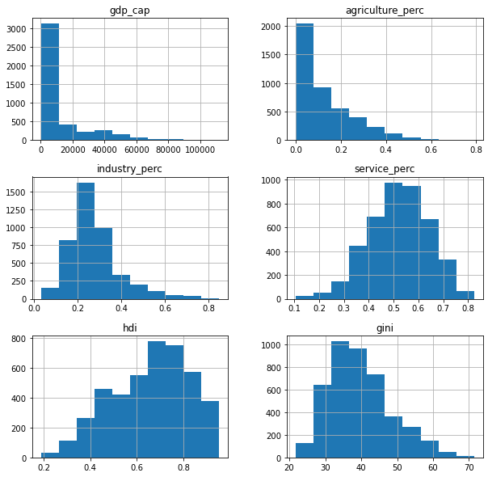

```python
df.iloc[:,2:].hist(figsize = (10,10));
df.iloc[:,2:].describe()
```

```python
columns = df.columns.tolist()
columns
```

```
['country',
 'year',
 'gdp_cap',
 'agriculture_perc',
 'industry_perc',
 'service_perc',
 'hdi',
 'gini']
```

|  | gdp_cap | agriculture_perc | industry_perc | service_perc | hdi | gini |
| --- | --- | --- | --- | --- | --- | --- |
| mean | 11998.984054 | 0.129190 | 0.276475 | 0.519892 | 0.657916 | 39.629512 |
| std | 17458.751270 | 0.122048 | 0.118573 | 0.119996 | 0.166076 | 8.685405 |
| min | 195.000000 | 0.000284 | 0.031500 | 0.106000 | 0.189000 | 21.800000 |
| max | 112000.000000 | 0.790000 | 0.848000 | 0.824000 | 0.954000 | 71.400000 |

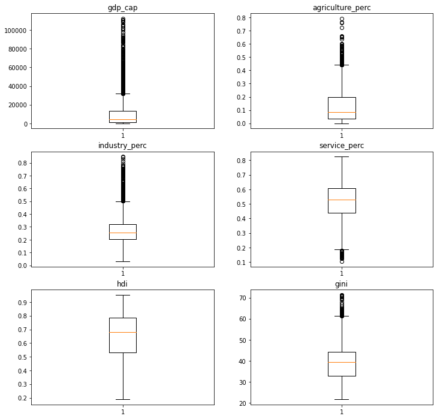

```python
fig, axs = plt.subplots(3,2, figsize = (12,12))
axs[0,0].boxplot(df['gdp_cap'])
axs[0,0].set_title('gdp_cap')

axs[0,1].boxplot(df['agriculture_perc'])
axs[0,1].set_title('agriculture_perc')

axs[1,0].boxplot(df['industry_perc'])
axs[1,0].set_title('industry_perc')

axs[1,1].boxplot(df['service_perc'])
axs[1,1].set_title('service_perc')

axs[2,0].boxplot(df['hdi'])
axs[2,0].set_title('hdi')

axs[2,1].boxplot(df['gini'])
axs[2,1].set_title('gini')
;
df.describe().loc[['mean', 'std', 'min', 'max'],columns[2:]]
```

## 1) Findings:

- gdp_cap: very skewed to the right 75% of the countries are below 13.6K
- industry_perc: Skewed to the right Mean is 0.27 75% of the countries are below 0.32
- agriculture_perc: Very skewed to the riht Meand is 0.13 75% of the countries are below 0.197
- service_perc: Skewed to the left Mean is 0.52 75% of the countries are above 0.437
- hdi Skewed to the left Mean is 0.657 75% of the countries are above 0.53 no outliers
- gini Skewed to the right Mean is 39.63 75% of the countries are below 44.3 there are high outliers (above 60aprox)

Insights

## 2) Correlations

|  | gdp_cap | agriculture_perc | industry_perc | service_perc | hdi | gini |
| --- | --- | --- | --- | --- | --- | --- |
| gdp_cap | 1.000000 | -0.528603 | 0.048356 | 0.449596 | 0.692040 | -0.367560 |
| agriculture_perc | -0.528603 | 1.000000 | -0.334892 | -0.588516 | -0.809073 | 0.110687 |
| industry_perc | 0.048356 | -0.334892 | 1.000000 | -0.484948 | 0.126363 | 0.048363 |
| service_perc | 0.449596 | -0.588516 | -0.484948 | 1.000000 | 0.591192 | -0.086128 |
| hdi | 0.692040 | -0.809073 | 0.126363 | 0.591192 | 1.000000 | -0.365146 |
| gini | -0.367560 | 0.110687 | 0.048363 | -0.086128 | -0.365146 | 1.000000 |

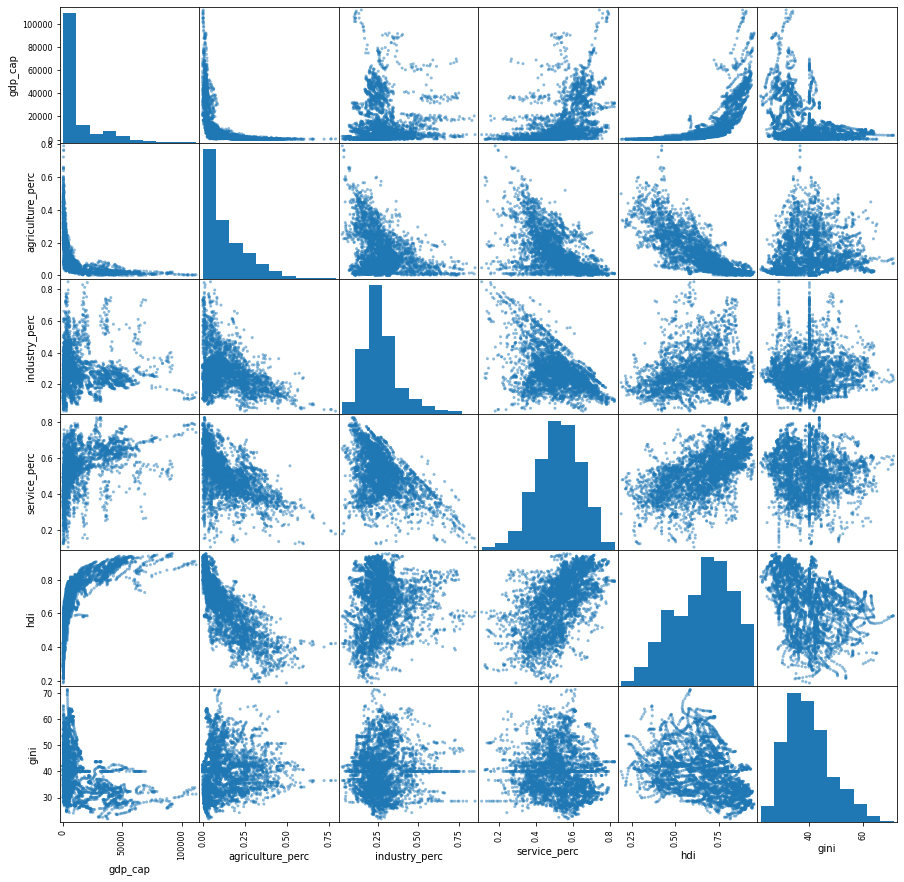

```python
pd.plotting.scatter_matrix(df.iloc[:,2:], figsize = (15,15));
corr = df.iloc[:,2:].corr('pearson')
corr
```

```python
# we rank the pearson values to better observe our findings.
# we will assume correlation when pearson modules is greater than 0.69.
for i in corr:
    corr[i] = pd.cut(x = corr[i],
                     bins = [-1,-0.69,-0.20,0.2,0.69,1],
                     labels = ("neg_corr", "low_neg_corr", "no_corr", "low_pos_corr", "pos_corr")
                    )
corr
```

|  | gdp_cap | agriculture_perc | industry_perc | service_perc | hdi | gini |
| --- | --- | --- | --- | --- | --- | --- |
| gdp_cap | pos_corr | low_neg_corr | no_corr | low_pos_corr | pos_corr | low_neg_corr |
| agriculture_perc | low_neg_corr | pos_corr | low_neg_corr | low_neg_corr | neg_corr | no_corr |
| industry_perc | no_corr | low_neg_corr | pos_corr | low_neg_corr | no_corr | no_corr |
| service_perc | low_pos_corr | low_neg_corr | low_neg_corr | pos_corr | low_pos_corr | no_corr |
| hdi | pos_corr | neg_corr | no_corr | low_pos_corr | pos_corr | low_neg_corr |
| gini | low_neg_corr | no_corr | no_corr | no_corr | low_neg_corr | pos_corr |

## 2) Findings

- gini has little correlation with hdi and gdp_cap, and no correlation with the other variables. This suggests that the chosen variables might not be quite relevant for understanding gini.
- hdi has: strong correlation with gdp_cap, agriculture_perc. no correlation with industry_perc This suggests that the chosen variables might not be quite relevant for understanding hdi.
- gdp_cap has low correlation with the economy sector percentage. This is relevant since it may imply that the productivity or efficiency of the resources does not strictly depends on the activity. Meaning that difference might be in the better use of them, and not in the activity perse. Since this is very high level analysis, further exploration may be needed regarding the details for each economic sector.

## 3) Trending (All dataset)

mean for each variable is trended vs year

```
''
```

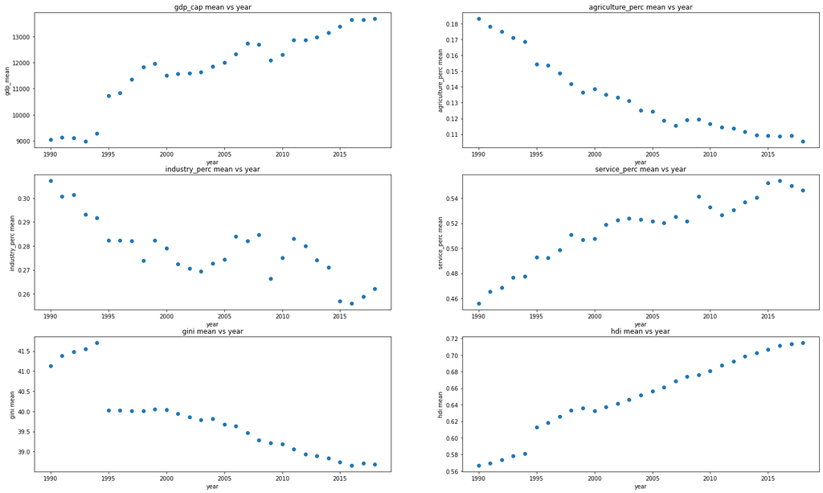

```python
fig, axs = plt.subplots(3,2, figsize = (25,15))

y = df['year'].unique()

axs[0,0].scatter(x = y, y = df.groupby('year').gdp_cap.mean())
axs[0,0].set_xlabel('year')
axs[0,0].set_ylabel('gdp_mean')
axs[0,0].set_title('gdp_cap mean vs year')

axs[0,1].scatter(x = y, y = df.groupby('year').agriculture_perc.mean())
axs[0,1].set_xlabel('year')
axs[0,1].set_ylabel('agriculture_perc mean')
axs[0,1].set_title('agriculture_perc mean vs year')

axs[1,0].scatter(x = y, y = df.groupby('year').industry_perc.mean())
axs[1,0].set_xlabel('year')
axs[1,0].set_ylabel('industry_perc mean')
axs[1,0].set_title('industry_perc mean vs year')

axs[1,1].scatter(x = y, y = df.groupby('year').service_perc.mean())
axs[1,1].set_xlabel('year')
axs[1,1].set_ylabel('service_perc mean')
axs[1,1].set_title('service_perc mean vs year')

axs[2,1].scatter(x = y, y = df.groupby('year').hdi.mean())
axs[2,1].set_xlabel('year')
axs[2,1].set_ylabel('hdi mean')
axs[2,1].set_title('hdi mean vs year')

axs[2,0].scatter(x = y, y = df.groupby('year').gini.mean())
axs[2,0].set_xlabel('year')
axs[2,0].set_ylabel('gini mean')
axs[2,0].set_title('gini mean vs year')
;
```

## 3) Findings

- gdp_cap mean has been increased over the years. There is a clear jump up near 1995, and two step downs near 2000 and 2008. Further analysis is needed to review if there was any global crisis near those years. This also means that in the last years, the capacity to produce has inreased.
- industry_perc mean has decreased over the years
- agriculture_perc mean has decreased over the years
- service_perc mean has increased over the years These last three points might imply that the most added value to the economy is in the service sector.
- gini mean has decreased over the years (more equality)
- hdi mean has increased over the years (more human development) These last two points mean that watching all the countries as a whole, humanity is getting better. However the timeframe is near 30 years, meaning (statiscally) that we might not be catching representative information.

## 4) Trending for high and low hdi level

- First the dataset will be cut by hdi cuartiles. This will be convenient to rank and group "similar" countries.
- Thereafter mean for each variable will be trended for highest and lowest cuartile. We will try to explore the most desirable and the less desirable condition for hdi.

```python
df['hdi_levels'] = pd.qcut(df['hdi'], q = 4, labels = ['low_low', 'mid_low', 'mid_high', 'high_high'])
df.head()
```

|  | country | year | gdp_cap | agriculture_perc | industry_perc | service_perc | hdi | gini | hdi_levels |
| --- | --- | --- | --- | --- | --- | --- | --- | --- | --- |
| 0 | Argentina | 1990 | 6250.0 | 0.0812 | 0.360 | 0.559 | 0.707 | 46.1 | mid_high |
| 1 | Australia | 1990 | 35900.0 | 0.0421 | 0.289 | 0.594 | 0.866 | 33.0 | high_high |
| 2 | Austria | 1990 | 33900.0 | 0.0310 | 0.296 | 0.561 | 0.795 | 28.5 | high_high |
| 3 | Bangladesh | 1990 | 411.0 | 0.3050 | 0.201 | 0.467 | 0.388 | 28.2 | low_low |
| 4 | Barbados | 1990 | 14400.0 | 0.0344 | 0.187 | 0.710 | 0.732 | 46.7 | mid_high |

```
''
```

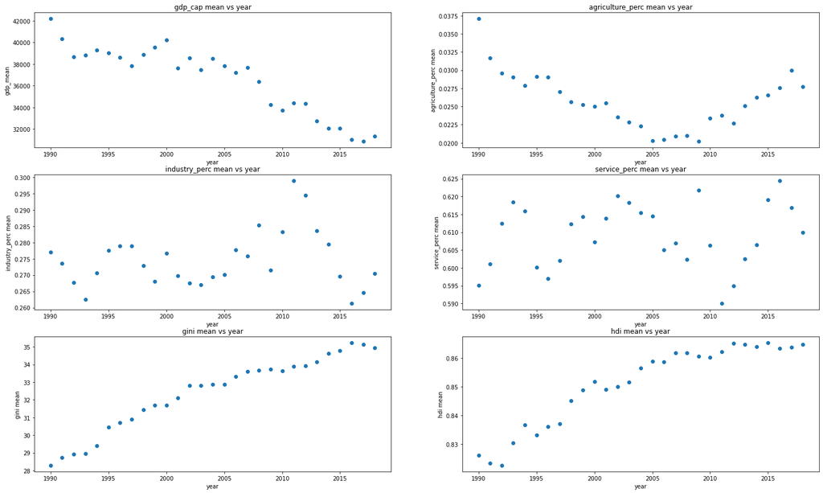

```python
df_highhigh = df.query('hdi_levels =="high_high"')

fig, axs = plt.subplots(3,2, figsize = (25,15))

y = df_highhigh['year'].unique()

axs[0,0].scatter(x = y, y = df_highhigh.groupby('year').gdp_cap.mean())
axs[0,0].set_xlabel('year')
axs[0,0].set_ylabel('gdp_mean')
axs[0,0].set_title('gdp_cap mean vs year')

axs[0,1].scatter(x = y, y = df_highhigh.groupby('year').agriculture_perc.mean())
axs[0,1].set_xlabel('year')
axs[0,1].set_ylabel('agriculture_perc mean')
axs[0,1].set_title('agriculture_perc mean vs year')

axs[1,0].scatter(x = y, y = df_highhigh.groupby('year').industry_perc.mean())
axs[1,0].set_xlabel('year')
axs[1,0].set_ylabel('industry_perc mean')
axs[1,0].set_title('industry_perc mean vs year')

axs[1,1].scatter(x = y, y = df_highhigh.groupby('year').service_perc.mean())
axs[1,1].set_xlabel('year')
axs[1,1].set_ylabel('service_perc mean')
axs[1,1].set_title('service_perc mean vs year')

axs[2,1].scatter(x = y, y = df_highhigh.groupby('year').hdi.mean())
axs[2,1].set_xlabel('year')
axs[2,1].set_ylabel('hdi mean')
axs[2,1].set_title('hdi mean vs year')

axs[2,0].scatter(x = y, y = df_highhigh.groupby('year').gini.mean())
axs[2,0].set_xlabel('year')
axs[2,0].set_ylabel('gini mean')
axs[2,0].set_title('gini mean vs year')
;
```

```
''
```

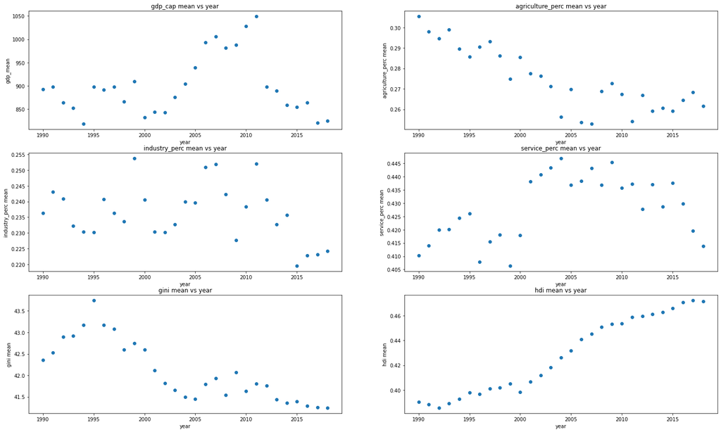

```python
df_lowlow = df.query('hdi_levels == "low_low"')
fig, axs = plt.subplots(3,2, figsize = (25,15))

y = df_lowlow['year'].unique()

axs[0,0].scatter(x = y, y = df_lowlow.groupby('year').gdp_cap.mean())
axs[0,0].set_xlabel('year')
axs[0,0].set_ylabel('gdp_mean')
axs[0,0].set_title('gdp_cap mean vs year')

axs[0,1].scatter(x = y, y = df_lowlow.groupby('year').agriculture_perc.mean())
axs[0,1].set_xlabel('year')
axs[0,1].set_ylabel('agriculture_perc mean')
axs[0,1].set_title('agriculture_perc mean vs year')

axs[1,0].scatter(x = y, y = df_lowlow.groupby('year').industry_perc.mean())
axs[1,0].set_xlabel('year')
axs[1,0].set_ylabel('industry_perc mean')
axs[1,0].set_title('industry_perc mean vs year')

axs[1,1].scatter(x = y, y = df_lowlow.groupby('year').service_perc.mean())
axs[1,1].set_xlabel('year')
axs[1,1].set_ylabel('service_perc mean')
axs[1,1].set_title('service_perc mean vs year')

axs[2,1].scatter(x = y, y = df_lowlow.groupby('year').hdi.mean())
axs[2,1].set_xlabel('year')
axs[2,1].set_ylabel('hdi mean')
axs[2,1].set_title('hdi mean vs year')

axs[2,0].scatter(x = y, y = df_lowlow.groupby('year').gini.mean())
axs[2,0].set_xlabel('year')
axs[2,0].set_ylabel('gini mean')
axs[2,0].set_title('gini mean vs year')
;
```

## 4) Findings

#### High hdi level

- gdp_cap mean has decreased. However, being above 32k(aprox) we are in the outliers range (from the boxplot analysis above)
- industry_perc mean looks oscillative
- agriculture_perc mean looks decreasing from the 90s to 2010, and then increasing until 2017
- service_perc mean looks very oscillative We see that there is not a straightforward correaltion between the economic sector percentages and the HDI level.
- gini mean has inreased
- hdi has incresed and looks stable from 2012 to 2018.

## 5) Comparing year 2000 vs 2018. HDI vs each variable

- Two datasets will be created for 2000 and 2018.
- Each variable will be inspected visually for each hdi level

The idea is to get a picture of two moments and try to understand what changes have been made in order to obtain some particular results regarding the HDI level.

```python
df_2000 = df.query('year ==2000')
df_2018 = df.query('year ==2018')
```

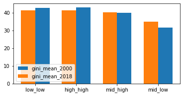

```python
#caracterizar cada bucket según media, de cada variable
#para el 2018 hacer un grafico de barra comparando cada variable vs highhigh lowlow etc
gini_2018 = df_2018.groupby('hdi_levels').gini.mean()
gini_2000 = df_2000.groupby('hdi_levels').gini.mean()

x = df_2018['hdi_levels'].unique()
width = 0.35
fig, ax = plt.subplots(figsize = (6,3))
rects1 = ax.bar(x = x, height = gini_2000, width = width, align = 'edge', label = 'gini_mean_2000')
rects2 = ax.bar(x = x, height = gini_2018, width = -width, align = 'edge', label = 'gini_mean_2018')
ax.legend(loc = 3);
```

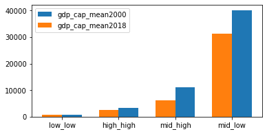

```python
gdp_cap_2018 = df_2018.groupby('hdi_levels').gdp_cap.mean()
gdp_cap_2000 = df_2000.groupby('hdi_levels').gdp_cap.mean()

width = 0.35
x = df_2018['hdi_levels'].unique()

fig, ax = plt.subplots(figsize = (6,3))
rects1 = ax.bar(x = x, height = gdp_cap_2000, width = width, align = 'edge', label ='gdp_cap_mean2000')
rects2 = ax.bar(x = x, height = gdp_cap_2018, width = -width, align = 'edge', label = 'gdp_cap_mean2018')
ax.legend(loc=2);
```

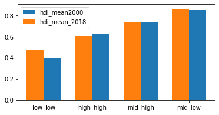

```python
hdi_2018 = df_2018.groupby('hdi_levels').hdi.mean()
hdi_2000 = df_2000.groupby('hdi_levels').hdi.mean()

width = 0.35
x = df_2018['hdi_levels'].unique()

fig, ax = plt.subplots(figsize = (6,3))
rects1 = ax.bar(x = x, height = hdi_2000, width = width, align = 'edge', label ='hdi_mean2000')
rects2 = ax.bar(x = x, height = hdi_2018, width = -width, align = 'edge', label = 'hdi_mean_2018')
ax.legend(loc=2);
```

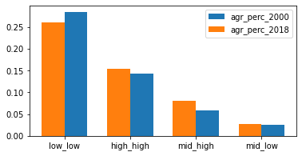

```python
agr_perc_2018 = df_2018.groupby('hdi_levels').agriculture_perc.mean()
agr_perc_2000 = df_2000.groupby('hdi_levels').agriculture_perc.mean()

width = 0.35
x = df_2018['hdi_levels'].unique()

fig, ax = plt.subplots(figsize = (6,3))
rects1 = ax.bar(x = x, height = agr_perc_2000, width = width, align = 'edge', label ='agr_perc_2000')
rects2 = ax.bar(x = x, height = agr_perc_2018, width = -width, align = 'edge', label = 'agr_perc_2018')
ax.legend(loc=1);
```

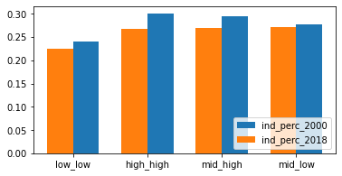

```python
ind_perc_2018 = df_2018.groupby('hdi_levels').industry_perc.mean()
ind_perc_2000 = df_2000.groupby('hdi_levels').industry_perc.mean()

width = 0.35
x = df_2018['hdi_levels'].unique()

fig, ax = plt.subplots(figsize = (6,3))
rects1 = ax.bar(x = x, height = ind_perc_2000, width = width, align = 'edge', label ='ind_perc_2000')
rects2 = ax.bar(x = x, height = ind_perc_2018, width = -width, align = 'edge', label = 'ind_perc_2018')
ax.legend(loc=4);
```

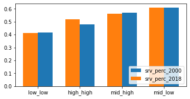

```python
srv_perc_2018 = df_2018.groupby('hdi_levels').service_perc.mean()
srv_perc_2000 = df_2000.groupby('hdi_levels').service_perc.mean()

width = 0.35
x = df_2018['hdi_levels'].unique()

fig, ax = plt.subplots(figsize = (6,3))
rects1 = ax.bar(x = x, height = srv_perc_2000, width = width, align = 'edge', label ='srv_perc_2000')
rects2 = ax.bar(x = x, height = srv_perc_2018, width = -width, align = 'edge', label = 'srv_perc_2018')
ax.legend(loc=4);
```

## 5) Findings

Comparing 2000 and 2018 datasets:

Insight:

To find patterns for HDI improvement it is suggested to further explore in the low_low group.

## 6) Countries in highest and lowest hdi level groups

A list including the scpecific countries for these two groups is provided to analyze which countries started to belong to each category comparing the years 2000 and 2018.

In order to explore how to get to the desirable condition of having a high HDI level, and avoid the undesirable condition of having a low HDI level, further exploration might be performed in those particular countries. (provided below)

This will also show how stable are the countries of each group regarding the HDI level.

### List of countries that were at the highest hdi level in 2000, and are still there in 2018.

```python
static_highigh_df = pd.merge(right = df_2000.query('hdi_levels == "high_high"'),
        left = df_2018.query('hdi_levels == "high_high"'),
        right_on = 'country',
         left_on = 'country',
        how = 'inner')
static_highhigh_countries = static_highigh_df['country'].tolist()
static_highhigh_countries
```

```
['Australia',
 'Austria',
 'Belgium',
 'Brunei',
 'Cyprus',
 'Czech Republic',
 'Denmark',
 'Finland',
 'France',
 'Germany',
 'Greece',
 'Iceland',
 'Ireland',
 'Israel',
 'Italy',
 'Japan',
 'Luxembourg',
 'Netherlands',
 'Norway',
 'Singapore',
 'Slovenia',
 'South Korea',
 'Spain',
 'Sweden',
 'Switzerland',
 'United Kingdom']
```

### List of countries that are at the highes hdi level in 2018 but weren't there in 2000.

```python
recent_highigh_countries = list()
for i in df_2018.query('hdi_levels == "high_high"')['country'].tolist():
    if i in static_highhigh_countries:
        pass
    else:
        recent_highigh_countries.append(i)
recent_highigh_countries
```

```
['Albania',
 'Argentina',
 'Bahamas',
 'Bahrain',
 'Belarus',
 'Bulgaria',
 'Chile',
 'Costa Rica',
 'Croatia',
 'Estonia',
 'Hungary',
 'Kazakhstan',
 'Kuwait',
 'Latvia',
 'Lithuania',
 'Malaysia',
 'Malta',
 'Mauritius',
 'Montenegro',
 'Oman',
 'Palau',
 'Panama',
 'Poland',
 'Portugal',
 'Qatar',
 'Romania',
 'Russia',
 'Saudi Arabia',
 'Serbia',
 'Seychelles',
 'Slovak Republic',
 'Trinidad and Tobago',
 'Turkey',
 'United Arab Emirates',
 'Uruguay']
```

```python
len(df_2018.query('hdi_levels =="high_high"')['country'].tolist()) == \
                            len(recent_highigh_countries) + len(static_highhigh_countries)
```

```
True
```

### List of countries that were at the lowest level in 2000 and are still there in 2018

```python
static_lowlow_df = pd.merge(right = df_2000.query('hdi_levels == "low_low"'),
                                 left = df_2018.query('hdi_levels == "low_low"'),
                                 right_on = 'country',
                                 left_on = 'country',
                                 how = 'inner')
static_lowlow_countries = static_lowlow_df['country'].tolist()
static_lowlow_countries
```

```
['Benin',
 'Burkina Faso',
 'Burundi',
 'Chad',
 'Congo, Dem. Rep.',
 "Cote d'Ivoire",
 'Ethiopia',
 'Gambia',
 'Guinea',
 'Haiti',
 'Lesotho',
 'Liberia',
 'Madagascar',
 'Malawi',
 'Mali',
 'Mauritania',
 'Mozambique',
 'Niger',
 'Senegal',
 'Sierra Leone',
 'Sudan',
 'Togo',
 'Uganda',
 'Yemen']
```

### List of countries that are at the lowest level in 2018 but weren't there in 2000

```python
recent_lowlow_countries = list()
for i in df_2018.query('hdi_levels == "low_low"')['country'].tolist():
    if i in static_lowlow_countries:
        pass
    else:
        recent_lowlow_countries.append(i)
recent_lowlow_countries
```

```
['Afghanistan', 'Central African Republic', 'Guinea-Bissau']
```

```python
len(df_2018.query('hdi_levels == "low_low"')['country'].tolist()) == \
                    len(static_lowlow_countries) + len(recent_lowlow_countries)
```

```
True
```

## Conclusion

From individual variables datasets it was created one dataset to analyze and explore. The analysis has been oriented to discover relationships between hdi and other variables, such as gini, gdp_cap, and economy sectors percentage. It was explored each variable for each quartile of hdi level, en two differente time points. lastly, it is provided a detailed list of "stable" and "recent" countries for the highest and lowest hdi levels.

For each question the finding was provided.

### Limitations

All analyzed variables are economic variables, save but the HDI. Therefore, a more deeper analysis including health, education, or maybe politics variables is needed to draw more conclusions. The analyzed period is the last 30 years. It might be not representative of "bigger" processes. Variables might not be significant or relevant to explore the HDI, since it showed strong correlation only with gdp_cap and agriculture_perc. Therefore, further investigation is needed, including other variables.

## Resources

- gapminder.org: all datasets come from this website
- stackoverflow.com
- pandas.pydata.org
- matplotlib.org